# Métodos de Validación Cruzada

## Información

- Autor: **Jose Carlos Molano de Oro** y **Juan Pablo Prada Barrios**
- Universidad: Pontificia Universidad Javeriana
- Courso: Análisis Multivariado
- Semester: 2022-3
- Profesor: Marisol Garcia Peña
- Email del Autor: jose_molano@javeriana.edu.co

## Introducción

- En regresión la validación cruzada es un método efectivo que se usa para decidir, por ejemplo, el número de características subyacentes y para estimar el error promedio de predicción.
- Su principal objetivo es omitir parte de los datos para construir un modelo y predecir las muestras omitidas.
- La validación cruzada se puede contemplar para modelos de análisis de componentes principales.

### Definición (Según R. Bro - K. Kjeldahl)

La validación cruzada es una técnica estándar de remuestreo utilizada en muchas aplicaciones quimiométricas. Los resultados de la validación cruzada a menudo simplifican la selección de metaparámetros, como el número de componentes, y también brindan una base más realista para el análisis residual y de influencia.

### Definición para Servicios de Análisis y Minería de Datos (Microsoft Azure)

La validación cruzada es una técnica que se usa a menudo en el aprendizaje automático para evaluar la variabilidad de un conjunto de datos y la confiabilidad de cualquier modelo entrenado con ellos.

El componente del modelo de validación cruzada:

- Toma como entrada un conjunto de datos con etiquetas, junto con un modelo de clasificación o regresión no entrenado.
- Divide el conjunto de datos en varios subconjuntos (plegamientos).
- Crea un modelo en cada plegamiento
- Devuelve un conjunto de estadísticas de precisión para cada plegamiento.
  - Al comparar las estadísticas de precisión de todos los pliegues, puede interpretar la calidad del conjunto de datos.

El modelo de validación cruzada también devuelve probabilidades y resultados previstos para el conjunto de datos, por lo que podrá evaluar la confiabilidad de las predicciones

## Row-Wise Cross-Validation

Esta aproximación illustra un esquema de validación cruzada similar al que se usa en el software UNSCRAMBLER (Software reconocido por su uso simple para visualizaciones excepcionales de datos y uso avanzado de métodos multivariados).

Se busca un modelo PCA para una matriz de datos $\mathbf{X}$ en donde cada segmento individual, que consiste en un número definido de muestras completas, se omite a su vez. El segmento estará restringido a un objeto (una fila de $\mathbf{X}$); por lo tanto, esto se denomina “validación cruzada de dejar uno fuera”.

### Procedimiento

Para un máximo número de componentes $F$, se aplican los siguientes pasos:

Para un número de factores, $f=1,...,F$:

- Para muestras excluidas (o filas en donde mas de una es excluida) $i=1,...,I$:
  - Separe $\mathbf{X}(I \times J)$ en $\mathbf{X}^{-i}$ y $(\mathbf{x}^i)^T$, donde $\mathbf{X}^{-i}$ contiene todas las filas exceptuando la $i-esima$, y $(\mathbf{x}^i)^T$ es un vector fila que contiene solo la $i-esima$ fila.
  - Ajuste un modelo de PCA para $\mathbf{X}^{-i}$ resolviendo:
    $$\text{min}\mid\mid
    \mathbf{X}^{-i}-\mathbf{T}^{-i}\mathbf{P}^{(-i)T} \mid\mid_f^2$$
    donde $\mid\mid \mathbf{\cdot} \mid\mid_f^2$ define la norma cuadrada de Frobenius, $\mathbf{I}=\mathbf{P}^{(-i)T}\mathbf{P}^{-i}$ y $\mathbf{T}^{-i},\mathbf{P}^{-i}$, son de dimensión $(I-1)\times f$ y $J\times f$ respectivamente donde $J$ es el número de variables.
  - Proyecte $\mathbf{x}^i$ sobre las cargas y halle los puntajes de las muestras excluidas como:
    $$(\mathbf{t}^i)^T=(\mathbf{x}^i)^{T}\mathbf{P}^{-i}$$
  - Determine la variación residual de $\mathbf{x}^i$ como
    $$(\mathbf{e}^i)^T=(\mathbf{x}^i)^T-(\mathbf{x}^i)^T\mathbf{P}^{-i}\mathbf{P}^{(-i)T}$$
- Coleccione todos los residuales en $\mathbf{E}(I\times J\times F)$; una matriz $I \times J$ para cada número de componentes.
- Calcule la varianza de validación residual media y corrija para los grados de libertad, resultando en la predicción residual de suma de cuadrados de medias (mean predicted residual sum of squares (MPRESS)):

$$\text{MPRESS}(f)=\frac{1}{I(J-f)}\sum^I\sum^J
e^2_{ijf}$$

### Características

- La ecuación de las variaciones residuales y de los puntajes residuales de muestras excluidas muestran que las muestras excluidas $\mathbf{x}^i$ son usados para hallar el modelo de $\mathbf{x}^i$.
- Los residuales del modelo $\mathbf{x}^i$ no son independientes de $\mathbf{x}^i$, esto como resultado de un sobreajuste (entre mayor número de componentes hallan, menor seran los residuales). No es apropiado dado que el objetivo de la validación cruzada es evitar el sobreajuste mediante la estimación del modelo independientemente de los datos a ser modelados.

## Cross-validation of Wold

El esquema de validación cruzada de wold proporciona una forma de calcular la predicción suma residual de cuadrados (PRESS) bajo un patrón de exclusión específico y un criterio para la selección del número de componentes.

- En este método de validación cruzada, una secuencia de elementos individuales $x_{ij}$ son dejados por fuera de la diagonal y son considerados como “valores faltantes”.
- Se ajusta un modelo a los datos restantes y se calcula el ajuste del modelo a los elementos omitidos.
- El usuario elige el número de segmentos $K$.
- El conteo de elementos se realiza por filas (figura1), de esta forma, al completar K segmentos, todos los elementos habrán sido omitidos una vez.

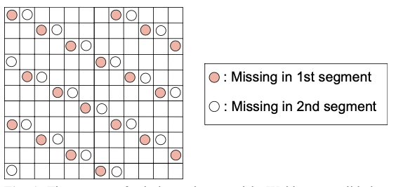

Fig. 1 El patrón de valores faltantes usando en la validación cruzada de Wold para $K=7$

### Procedimiento

Se busca un modelo PCA para una matrix $\mathbf{X}(I\times J)$, para validar el componente $f$, entonces:

- Sea $\mathbf{X}(f)$ los residuales despues de $f-1$ componentes. Inicialmente $\mathbf{X}(1)=\mathbf{X}$ y subsecuentemente $\mathbf{X}(f)$ es la matriz residual $\mathbf{E}(f-1)$.
- Calcule la suma de cuadrados de los elementos de $\mathbf{X}(f)$:

  $$SS_{\mathbf{X}(f)}=\sum^I\sum^Jx_{ij}^2(f)$$
- Para el segmento excluido $k=1,...,K$
  - Separe $\mathbf{X}(f)$ en $\mathbf{X}^{(-k)}(f)$ y $\mathbf{X}^{(k)}(f)$ en donde $\mathbf{X}^{(-k)}(f)$ contiene todas las observaciones excepto los elementos del $k-esimo$ segmento y $\mathbf{X}^{(k)}(f)$ contiene dicho segmento. -Estime el siguiente componente principal $(t^{-k},p^{-k})$ mediante el ajuste de $\mathbf{X}^{(-k)}(f)$ con el algoritmo NIPALS
  - Calcule el modelo de $\mathbf{X}^{(k)}(f)$ usando:
    $$\hat{x}_{ij}(f)=t_i^{-k}p_j^(-k)$$
  - Calcule la predicción suma residual de cuadrados (PRESS)

  $$\text{PRESS}(f)=\sum^I\sum^J\text{e}_{ij}^2(f)=\sum^I\sum^J(x_{ij}(f)-\hat{x}_{ij}(f))^2$$
- Halle $R$:
  - $R<1$ indica que las predicciones mejoran con la inclusión del último componente ($f$).
  - $R>1$ indica que el componente no mejoró los errores de predicción.

$$R(f)=\frac{\text{PRESS}(f)}{SS_{\mathbf{X}(f)}}$$

- Ajuste un modelo PCA $(\textbf{t,p})$ para el set de datos completos $\mathbf{X}(f)$ con un componente. Determine la variación residual como $\mathbf{E}(f)=\mathbf{X}(f)-\mathbf{tp}^T$
- Aumente $f$ en 1 y regrese al paso inicial.

## Cross-validation of Eastment and Krzanowski (EK o $K+E$)

En 1982 Eastment y Krzanowski sugieren una aproximación que puede ser usada para seleccionar un número factible de componentes principales.

El incentivo fue crear un enfoque de validación cruzada que garantizara que cada punto de datos no se usara en las etapas de predicción y evaluación, evitando así problemas de sobreajuste.

El enfoque tiene la intención de utilizar la mayor cantidad posible de datos originales para predecir un elemento omitido para cada posible elección de factores $f=1,...F(i=1,...,I\text{ y }j=1,...,J)$

### Procedimiento

- Para cada combinación de $i(1,...,I)$ y $j(1,...,J)$, un modelo de componentes principales es ajustado a $\mathbf{X}^{(-i)}$ y otro para $\mathbf{X}^{(-j)}$, es decir, se ajustan a los datos con la fila $i$ omitida y a los datos con la columna $j$ omitida. Los componentes principales son representados como una descomposición de valores singulares:

$$\mathbf{X}^{(-i)}=\mathbf{U}^{(-i)}\mathbf{S}^{(-i)}\mathbf{V}^{(-i)T}$$

$$\mathbf{X}^{(-j)}=\mathbf{U}^{(-j)}\mathbf{S}^{(-j)}\mathbf{V}^{(-j)T}$$

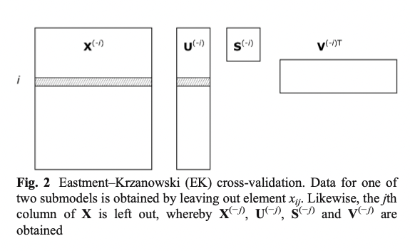

- Se tiene una representación gráfica de los datos para los componentes principales de $\mathbf{X}^{(-i)}$ en la figura 2, en donde la zona gris designa la parte de los datos (fila $i$) y no la parte del modelo. Ademas los parámetros $\mathbf{V}^{(-i)}$ y $\mathbf{S}^{(-i)}$ no son influenciados por la muestra $i$. las “cargas” en $\mathbf{V}^{(−i)}$ no proporcionan los medios para predecir la muestra $i$. Similarmente ocurre lo anterior para la muestra $j$.
- Mediante la combinación de 2 modelos, un estimador del elemento $x_{ij}$ puede ser obtenido en donde es independiente del valor de $x_{ij}$.
- Eastment y Krzanowski sugieren la combinación de dos modelos en donde es crucial en esta aproximación para combinar dos modelos en uno estimado.

$$\hat{x}_{ij}(f)=\sum^fu_i^{-1}(f)\sqrt{s^{-j}(f)}\sqrt{s^{-i}(f)}v_j^{-i}(f)$$

Las raíces cuadradas de los dos conjuntos de valores singulares se utilizan para adaptarse a las posibles diferencias en sus magnitudes. Para evitar problemas con indeterminaciones de signos Eastment y Krzanowski llamaron una “verificación de paridad”, donde los productos de las puntuaciones y cargas de los componentes, por componente, reciben el mismo signo que el producto correspondiente de las puntuaciones y cargas de los componentes encontrados para los datos completos.

- La predicción residual de suma de cuadrados de medias (mean predicted residual sum of squares (MPRESS)) expresa la diferencia de medias entre el actual y el valor predecido:
  - $D_{fit}(f)=I+J-2f$ es el número de grados de libertad perdido en el montaje del quinto componente
  - $D_r(f)$ es el número de grados de libertad restantes después del ajuste para $f$ componentes.
  - Previo al modelado y sin centrar, $D_r(f)=IJ$, así despues de ajustar $f$ factores $D_r(f)=IJ-\sum_1^f(I+J-2f)$

$$\text{MPRESS}(f)=\frac{\text{MPRESS}(f-1)-\text{MPRESS}(f)}{D_{fit}(f)}\div\frac{\text{MPRESS}(f)}{D_r(f)}$$
- Originalmente, Eastment y Krzanowski sugirieron que el factor $f$ debería incluirse siempre que $W(f)>1$; este umbral fue posteriormente modificado a un valor de 0,9 por Krzanowski

## Cross-validation by Eigenvector

- En este enfoque, los modelos de los factores principales se calculan con una o varias muestras omitidas y luego el modelo se usa para predecir las estimaciones de las muestras omitidas
- Suponiendo, sin pérdida de generalidad, que se utiliza la validación cruzada dejando uno fuera, se determina un modelo PCA a partir de las muestras restantes $I−1$.
- Para la muestra excluida:
  - Se estima un valor de puntaje para la muestra excluida en un sentido de mínimos cuadrados usando las variables restantes $J−1$ de esa muestra y el modelo PCA donde se excluyó la j-ésima fila de la matriz de carga.
  - Este valor de puntaje combinado con la matriz de carga PCA con todas las cargas variables incluidas da una estimación del elemento excluido $x_{ij}$.
- En esencia, se trata de un problema de datos faltantes en el que la variable faltante se predice a partir del modelo y la observación de la muestra excluye la única variable.

### Procedimiento

- Omita una o varias muestras y calcule un modelo PCA $(\mathbf{T,P})$ sobre el resto.
- Para cada factor $f=1,...,F$, y para la muestra omitida $i=1,...,I$ entonces:
  - Estime su puntaje como

    $$\mathbf{t}^{(-j)T}=\mathbf{x}_i^{(-j)T}\mathbf{P}^{(-j)}(\mathbf{P}^{(-j)T}\mathbf{P}^{(-j)})$$

    donde $\mathbf{P}^{(-j)}$ es la matriz de carga $\mathbf{P}$ encontrada primer paso con la $j-ésima$ fila excluida. $\mathbf{x}_i^{(-j)T}$ es un vector fila que contiene la $i-esima$ fila de $\mathbf{x}$ exceptuando el $j-esimo$ elemento.
  - Estime el elemento $x^{ij}$ como $\hat{x}_{ij}(f)=\mathbf{t}^{(-j)}\mathbf{p}_j^{T}$, donde $\textbf{j}$ es la $j-esima$ fila de $\textbf{p}$
  - Halle el error predictivo del $(i,j)-esimo$ elemento: $e_{ij}(f)=x_{ij}-\hat{x}_{ij}(f)$
- Estime la predicción suma residual de cuadrados (PRESS)

$$\text{PRESS}(f)=\sum^I\sum^J(e_{ij}(f))^2$$

### Caracteristicas de la validación cruzada de vectores propios

- Los valores de la predicción suma residual de cuadrados (PRESS) mediante el método de vectores propios son independientes de los elementos predecidos.
- El método del vector propio, al igual que el método por filas, tiene la ventaja de que las medidas de error específicas de la muestra, como la repetibilidad y la reproducibilidad, se pueden calcular basándose en la omisión de muestras en diferentes patrones.

## EM cross-validations and EM-Wold

### EM cross-validations

Se presentan dichos problemas con los modelos presentados:

- Se introduce un sobreajuste, porque el modelo con el que se predicen los elementos omitidos no es independiente de los elementos omitidos.
- Se introduce un error adicional no intencionado porque la lógica detrás del método no es correcta

Para dar solución a lo anterior, se presenta una validación cruzada basado en una mejora del procedimiento de Wold (EM-Wold)

### EM-Wold

- Consiste en elimina el problema con el método original de Wold al estimar todos los componentes simultáneamente para cada segmento
- El enfoque NIPALS para manejar valores faltantes deja de ser factible
- Los modelos de componentes principales completos se calculan para cada número de componentes mediante imputación.

### Procedimiento EM-Wold

Para factores $f=1,...,F$ y para el elemento omitido $k=1,...,IJ$:

- Particione los datos en $\mathbf{X}^{-k}$ y $x^{-k}$, donde $\mathbf{X}^{-k}$ contiene todos los datos excepto el $k-esimo$ elemento de $x_k$.
- Ajuste un modelo de componentes principales a $\mathbf{X}^{-k}$ resolviendo: $\text{min}\mid\mid\mathbf{X}^{-k}-\textbf{TP}^T\mid\mid_f^2$.
- Halle el modelo para el dataset completo como $\hat{\mathbf{X}}(f)=\mathbf{TP}^T$
- Determine el residual del elemento omitido como: $e_k(f)+x_k-\hat{x}_k(f)$
- Calcule la predicción suma residual de cuadrados (PRESS):

$$\text{PRESS}(f)=\frac{1}{IJ}\sum^{k=IJ}(e_k(f))^2$$

Se puede apreciar que la predicción del elemento omitido es independiente del elemento omitido, y el método de estimación no introduce ningún error adicional porque el modelo PCA se estima en un sentido de mínimos cuadrados.

## Cross-validation based on an improved Eastment and Krzanowski procedure (EM-EK)

Es una mejora del procedimiento de Eastment y Krzanowski. El método consiste en un simple remedio antes de igualar las puntuaciones y las cargas.

La suposición en el enfoque de Eastment y Krzanowski es que para un elemento excluido dado, $x_{ij}$, el modelo del elemento está definido por los subespacios dados por $\mathbf{U}^{(−j)}$ y $\mathbf{V}^{(−i)}$.

Luego la escala y la rotación no estan definidas inmediatamente. En orden para definir para definirlo, se halla un modelo basado en $\mathbf{U}^{(-j)}$ y $\mathbf{V}^{(-i)}$ para maximizar el ajuste de los datos que no han sido omitidos. Lo anterior es posible gracias a un modelo iterativo en donde el modelo de $\mathbf{X}^{-ij}$ es determinada por:

$$\hat{\mathbf{X}}=(\mathbf{U}^{(-j)}(\mathbf{U}^{(-j)})^+)\mathbf{X}^{(-ij)}(\mathbf{V}^{(-i)}\mathbf{V}^{(-i)})^T$$

Por lo tanto, obtenemos una proyección sobre los espacios abarcados por las puntuaciones y cargas dadas sin suponer que las columnas de estos están emparejadas por pares.

## Referencias

- https://learn.microsoft.com/es-es/analysis-services/data-mining/cross-validation-analysis-services-data-mining?view=asallproducts-allversions
- https://learn.microsoft.com/es-es/azure/machine-learning/component-reference/cross-validate-model
- https://www.capterra.com/p/118853/The-Unscrambler-X/
- Bro, Rasmus & Kjeldahl, K & Smilde, A.K. & Kiers, Henk. (2008). Cross-validation of component models: A critical look at current methods. Analytical and bioanalytical chemistry. 390. 1241-51. 10.1007/s00216-007-1790-1.
- Eshghi, P. (2014). Dimensionality choice in principal components analysis via cross-validatory methods. Chemometrics and Intelligent Laboratory Systems, 130, 6–13. https://doi.org/10.1016/j.chemolab.2013.09.004